# Sample questions

# Part 1 (Wrangling data with dplyr)

For the next several questions, use the following dataset.

```r
library(gapminder)
gapminder
```

```
## # A tibble: 1,704 x 6
##    country     continent  year lifeExp      pop gdpPercap
##    <fct>       <fct>     <int>   <dbl>    <int>     <dbl>
##  1 Afghanistan Asia       1952    28.8  8425333      779.
##  2 Afghanistan Asia       1957    30.3  9240934      821.
##  3 Afghanistan Asia       1962    32.0 10267083      853.
##  4 Afghanistan Asia       1967    34.0 11537966      836.
##  5 Afghanistan Asia       1972    36.1 13079460      740.
##  6 Afghanistan Asia       1977    38.4 14880372      786.
##  7 Afghanistan Asia       1982    39.9 12881816      978.
##  8 Afghanistan Asia       1987    40.8 13867957      852.
##  9 Afghanistan Asia       1992    41.7 16317921      649.
## 10 Afghanistan Asia       1997    41.8 22227415      635.
## # … with 1,694 more rows
```

- Q1: What is the most accurate way to compute the average life expectancy for each continent in 1952 ?

```r
## (a)
gapminder %>% filter(year == 1952) %>% summarise(avg_life_Exp = mean(lifeExp))

## (b)
gapminder %>% filter(year == 1952) %>% mutate(total_life = lifeExp*pop) %>%
                  summarise(avg_life_Exp = mean(total_life))

## (c)
gapminder %>% group_by(continent) %>% filter(year == 1952) %>%
  mutate(total_life = lifeExp*pop) %>%
  summarise(total_life = sum(total_life), total_pop = sum(pop)) %>%
  mutate(avg_life_Exp = total_life/total_pop)

## (d)
gapminder %>% filter(year == 1952) %>% group_by(continent) %>%
  summarise(avg_life_Exp = mean(lifeExp))
```

**Answer** (c) as we need to compute the weighted average (as the population for each country differs)

- Q2: How will you compute, for each year, the standardized gdpPercap for each country (standardized by the continent the country belongs to) ?

```r
library(dplyr)

## (a)
gapminder %>% group_by(year) %>% mutate(std_gdp = scale(gdpPercap))

## (b)
gapminder %>% group_by(continent, year) %>% mutate(std_gdp = scale(gdpPercap))

## (c)
gapminder %>% group_by(continent, year) %>% summarise(std_gdp = scale(gdpPercap))

## (d)
gapminder %>% group_by(year) %>% summarise(std_gdp = scale(gdpPercap))
```

**Answer** (b) you need to do a grouped mutate; here the mutate (standardization) are based on the different continent and different year.

- Q3: The following table is obtained by splitting the **gapminder** data into $3$ groups based on the logarithm of gdpPercap in $1952$ (these buckets corresponds roughly the “undeveloped”, “developing”, and “developed” countries at that time) and then find the country with the sharpest population increase between $1952$ and $2007$, **grouped by the original development status in $1952$**. Which of the following code will reproduce this table ?

```
## # A tibble: 6 x 8
## # Groups:   develop [3]
##   country continent  year lifeExp     pop gdpPercap develop pop_growth
##   <fct>   <fct>     <int>   <dbl>   <int>     <dbl>   <int>      <dbl>
## 1 Gambia  Africa     1952    30    284320      485.       1       5.94
## 2 Gambia  Africa     2007    59.4 1688359      753.       1       5.94
## 3 Jordan  Asia       1952    43.2  607914     1547.       2       9.96
## 4 Jordan  Asia       2007    72.5 6053193     4519.       2       9.96
## 5 Kuwait  Asia       1952    55.6  160000   108382.       3      15.7
## 6 Kuwait  Asia       2007    77.6 2505559    47307.       3      15.7
```

```r
## (a)
gapminder %>% mutate(develop = ntile(log(gdpPercap), 3)) %>% group_by(country) %>%
  mutate(pop_growth = pop[year == 2007]/pop[year == 1952]) %>%
  ungroup() %>% group_by(develop) %>%
  filter(pop_growth == max(pop_growth), year %in% c(1952, 2007))

## (b)
gapminder_1952 <- gapminder %>% filter(year == 1952) %>%
  mutate(develop = ntile(log(gdpPercap),3)) %>%
  select(country, develop)
gapminder %>% left_join(gapminder_1952) %>% group_by(country) %>%
  mutate(pop_growth = pop[year == 2007]/pop[year == 1952]) %>%
  ungroup() %>% group_by(develop) %>%
  filter(pop_growth == max(pop_growth), year %in% c(1952, 2007))

## (c)
gapminder_1952 <- gapminder %>% filter(year == 1952) %>%
  mutate(develop = ntile(log(gdpPercap),3))
gapminder %>% left_join(gapminder_1952) %>% group_by(country) %>%
  mutate(pop_growth = pop[year == 2007]/pop[year == 1952]) %>%
  filter(pop_growth == max(pop_growth), year %in% c(1952, 2007))

## (d)
gapminder %>% mutate(develop = ntile(log(gdpPercap), 3)) %>%
  group_by(country,develop) %>%
  mutate(pop_growth = pop[year == 2007]/pop[year == 1952]) %>%
  filter(pop_growth == max(pop_growth), year %in% c(1952, 2007))
```

**Answer** (b). The answer (c) might work, except that we do not want to join by **year**, only by **country** name, so we need to either remove year, or specify the join key explicitly.

# Part 2 (Base R datastructures and automation)

Consider the following list

```r
list1 <- list(a = list(1,2), b = list(3,3), c = list("a","b","c","d"))
```

- Q1. What is the length of $\mathtt{list1}$ ?
  $$\mathrm{(a)} 4; \quad \mathrm{(b)} 2; \quad \mathrm{(c)} 5; \quad \mathrm{(d)} 3$$

**Answer** (d) as **list1** is a list with $3$ elements.

- Q2. What is the length of $\mathtt{list1[2]}$ ?
  $$\mathrm{(a)} 1; \quad \mathrm{(b)} 2; \quad \mathrm{(c)} 3; \quad \mathrm{(d)} 4$$

**Answer** (a) as $[]$ returns a sub-list, in this case a list with $1$ element corresponding to the sub-list of $\mathtt{list1}$ with one element.

- Q3. What is the result of the following code chunk ?

```r
library(magrittr) ## This allows the use of the %>% operator
list1 %>% lapply(length) %>% sapply(unique)
```

$$\mathrm{(a)} [1,2,4]; \quad \mathrm{(b)} [2,2,4]; \quad \mathrm{(c)} [2,1,4]; \quad \mathrm{(d)} [2,4]$$

**Answer** (b) as the first $\mathtt{lapply}$ returns a list with three elements, each element being the length of $\mathtt{list1\$a}$, $\mathtt{list1\$b}$, $mathtt{list1\$c}$, and the $\mathtt{sapply}$ returns a vector, each element of which is obtained by calling unique on the elements obtained from the $\mathtt{lapply}$.

- Q4: What is the relationship between a list and a vector in **R** ?
  - 1. A list is a special type of vector.
  - 2. A vector is a special kind of list.
  - 3. A vector and a list are distinct data types.
  - 4. The intersection of a list and a vector is the **NULL** object.

**Answer** (a) (see slide 2 of the lecture slides on Vectors in **R**).

# Part 3 (Tidying Data)

Consider the following table, call it $\mathtt{table1}$.

```
## # A tibble: 6 x 5
##   country      year  cases population expense
##   <chr>       <dbl>  <dbl>      <dbl>   <dbl>
## 1 Afghanistan  1999    745   19987071     100
## 2 Afghanistan  2000   2666   20595360     150
## 3 Brazil       1999  37737  172006362     125
## 4 Brazil       2000  80488  174504898     200
## 5 China        1999 212258 1272915272     250
## 6 China        2000 213766 1280428583     175
```

- Q1. What is the dimension (number of rows and columns) of $\mathtt{table2}$ below ?

```r
table2 <- gather(table1, key = "type", value = "value", cases, population, expense) %>%
  arrange(country, year)
```

$$\mathrm{(a)} \text{12 and 5}; \quad \mathrm{(b)} \text{12 and 4}; \quad \mathrm{(c)} \text{18 and 4}; \quad \mathrm{(d)} \text{18 and 5}$$

**Answer** (c) (run the code)

- Q2. How will you go from $\mathtt{table1}$ to the following table

```
## # A tibble: 3 x 3
##   country         `1999`     `2000`
##   <chr>            <dbl>      <dbl>
## 1 Afghanistan   19987071   20595360
## 2 Brazil       172006362  174504898
## 3 China       1272915272 1280428583
```

```r
## (a)
table1 %>% select(-population,expense) %>% spread(year, cases)
## (b)
table1 %>% select(-cases,-expense) %>% spread(year, population)
## (c)
table1 %>% select(-population,-cases) %>% spread(year, expense)
## (d)
table1 %>% select(population,cases) %>% spread(year, population)
```

**Answer** (b) (run the code)

- Q3. How will you go from the following tables back to $\mathtt{table1}$ ? Denote these tables as $\mathtt{table\_abbr}$, $\mathtt{table5a}$ and $\mathtt{table5b}$.

| fullname | abbr |
| --- | --- |
| Afghanistan | AF |
| Brazil | BR |
| China | CN |
| France | FR |
| Spain | SP |

| country | year | cases | expense |
| --- | --- | --- | --- |
| Afghanistan | 1999 | 745 | 100 |
| Afghanistan | 2000 | 2666 | 150 |
| Brazil | 1999 | 37737 | 125 |
| Brazil | 2000 | 80488 | 200 |
| China | 1999 | 212258 | 250 |
| China | 2000 | 213766 | 175 |

| abbr | 1999 | 2000 |
| --- | --- | --- |
| AF | 2.00e+07 | 2.06e+07 |
| BR | 1.72e+08 | 1.75e+08 |
| CN | 1.27e+09 | 1.28e+09 |

```r
## (a)
table_abbr %>% right_join(table5b) %>% select(-abbr) %>%
  gather(key = "year", value = "population", `1999`, `2000`, convert = TRUE) %>%
  rename(country = fullname) %>% right_join(table5a)
## (b)
table_abbr %>% left_join(table5b) %>% select(-abbr) %>%
  gather(key = "year", value = "population", `1999`, `2000`, convert = TRUE) %>%
  rename(country = fullname) %>% left_join(table5a)
## (c)
table_abbr %>% left_join(table5b) %>% select(-abbr) %>%
  gather(key = "year", value = "population", `1999`, `2000`, convert = TRUE) %>%
  left_join(table5a)
## (d)
table_abbr %>% right_join(table5b) %>% select(-abbr) %>%
  gather(key = "year", value = "population", `1999`, `2000`, convert = TRUE) %>%
  left_join(table5a, by = c("fullname" = "country"))
```

**Answer** (a) (run the code). But more specifically, we want to keep **table5b** so we need a $\mathtt{right\_join}(\mathtt{table\_abbr}, \mathtt{table5b})$. In addition, we also need to join $\mathtt{table5a}$ using both country name and year, so option (d), which do a join using only country name, is wrong. In this case by renaming fullname to country, option (a) then allow us to join by both country name and year.

- Q4: How will you go from **table1** to the following table (call it **table_q4**) ? Here $\mathtt{means}$ contain the sample average for each variable

```r
table_q4
```

```
## # A tibble: 3 x 3
##   country     data             means
##   <chr>       <list>           <list>
## 1 Afghanistan <tibble [2 × 4]> <dbl [3]>
## 2 Brazil      <tibble [2 × 4]> <dbl [3]>
## 3 China       <tibble [2 × 4]> <dbl [3]>
```

```r
table_q4$means[[1]]
```

```
##      cases population    expense
##       1706   20291216        125
```

```r
colmeans <- function(df){
  sapply(select(df, -year), mean)
}

## (a)
table_q4 <- table1 %>% group_by(country) %>% nest() %>%
  mutate(means = map(data, colmeans)) %>% unnest()

## (b)
table_q4 <- table1 %>% group_by(country,year) %>% nest() %>% map(data, colmeans)
## (c)
table_q4 <- table1 %>% group_by(country) %>% nest() %>% map(data, colmeans)

## (d)
table_q4 <- table1 %>% group_by(country) %>% nest() %>%
  mutate(means = map(data, colmeans))
```

**Answer** (d) run the code

# Part 4 (Basic statistics and linear models)

```
## # A tibble: 40 x 4
##        Y     W     X     Z
##    <dbl> <dbl> <dbl> <dbl>
##  1  14.3  2.44     1     5
##  2  14.4  2.48     1     5
##  3  14.4  2.66     1     5
##  4  14.9  2.51     1     5
##  5  14.8  2.51     1     5
##  6  14.5  2.67     1     5
##  7  14.5  2.55     1     5
##  8  14.3  2.37     1     5
##  9  14.6  2.43     1     5
## 10  14.4  2.46     1     5
## # … with 30 more rows
```

The design matrix $\mathbf{X}$ satisfies

$$\mathbf{X} = \begin{bmatrix} 1 & X_1 & Z_1 & W_1 \\ 1 & X_2 & Z_2 & W_2 \\ \vdots & \vdots & \vdots \\ 1 & X_n & Z_n &
W_n \end{bmatrix}; \quad (\mathbf{X}^{T} \mathbf{X})^{-1}
= \begin{bmatrix} 12.18 & 0.28 & -2.65 & -2.15 \\ -0.28 & 3.2 & -0.06 & -1.64
\\ -2.65 & -0.06 & 0.58 & 0.47 \\ -2.15 & -1.64 & 0.47 & 1.18 \end{bmatrix}$$

The following output are the $95\%$ confidence interval obtained from **R** for fitting the model $Y_i = \beta_0 + \beta_W W_i + \beta_X X_i + \beta_Z Z_i + \epsilon_i$ to the data where the $\epsilon_i$ are assumed i.i.d. $N(0, \sigma^2)$.

```r
mod <- lm(Y ~ W + X + Z, df)
confint(mod, level = 0.95)
```

```
##              2.5 % 97.5 %
## (Intercept) 0.3965  3.150
## W           0.6285  2.038
## X           0.0196  0.623
## Z           1.3853  2.243
```

From the above ouput, answer the following question.

Q1. What is the least square estimate for $\hat{\beta}_W$ ?

$$\mathrm{(a)} 1.333; \quad \mathrm{(b)} 1.833; \quad \mathrm{(c)} 0.833; \quad \mathrm{(d)} 0.667$$

**Answer**: $\hat{\beta}_W$ is the mid-point of the $95\%$ confidence interval for $\beta_W$.

Q2. What is a reasonable estimate of $\sigma^2$ for this data (assuming the posited model is “correct”) ? You can assume that the $97.5\%$ quantile for the appropriate Student-$t$ distribution is $2$.
$$\mathrm{(a)} 1.038; \quad \mathrm{(b)} 0.195; \quad \mathrm{(c)} 0.038; \quad \mathrm{(d)} 0.019$$

Q3. What is a reasonable **prediction** interval for $Y_*$ when $\boldsymbol{x}_* = (W_*, X_*, Z_*) = (2,3,4)$ ? (This is a fill-in a blank question. You don’t have to provide the exact numbers but you need to demonstrate that you know how to obtain the answer from the output given above).

Q4. Can you conclude, from the above output, that (assuming the model is true), there is scant evidence supporting the hypothesis that $\beta_X = 0.65$ and $\beta_Z = 1$ **simultaneously** (with $\beta_0$ and $\beta_W$ arbitrary) ? Why or why not ?

**Answer** The marginal confidence intervals suggests that $\beta_X$ is unlikely to be $0.65$ and $\beta_Z$ is unlikely to be $1$. However, $(0.65,1)$ could potentially lie in the **joint** confidence region for $\beta_X$ and $\beta_Z$, but it is hard, without a computer, to see how the joint confidence region for $\beta_X$ and $\beta_Z$ looks like using only the above output.

# Part 5 (Visualizing data)

For this part, use the following dataset on highway efficiency of cars.

```r
mpg
```

```
## # A tibble: 234 x 11
##    manufacturer model displ  year   cyl trans drv     cty   hwy fl    class
##    <chr>        <chr> <dbl> <int> <int> <chr> <chr> <int> <int> <chr> <chr>
##  1 audi         a4      1.8  1999     4 auto… f        18    29 p     comp…
##  2 audi         a4      1.8  1999     4 manu… f        21    29 p     comp…
##  3 audi         a4      2    2008     4 manu… f        20    31 p     comp…
##  4 audi         a4      2    2008     4 auto… f        21    30 p     comp…
##  5 audi         a4      2.8  1999     6 auto… f        16    26 p     comp…
##  6 audi         a4      2.8  1999     6 manu… f        18    26 p     comp…
##  7 audi         a4      3.1  2008     6 auto… f        18    27 p     comp…
##  8 audi         a4 q…   1.8  1999     4 manu… 4        18    26 p     comp…
##  9 audi         a4 q…   1.8  1999     4 auto… 4        16    25 p     comp…
## 10 audi         a4 q…   2    2008     4 manu… 4        20    28 p     comp…
## # … with 224 more rows
```

Q1. Which code will reproduce the following figure ?

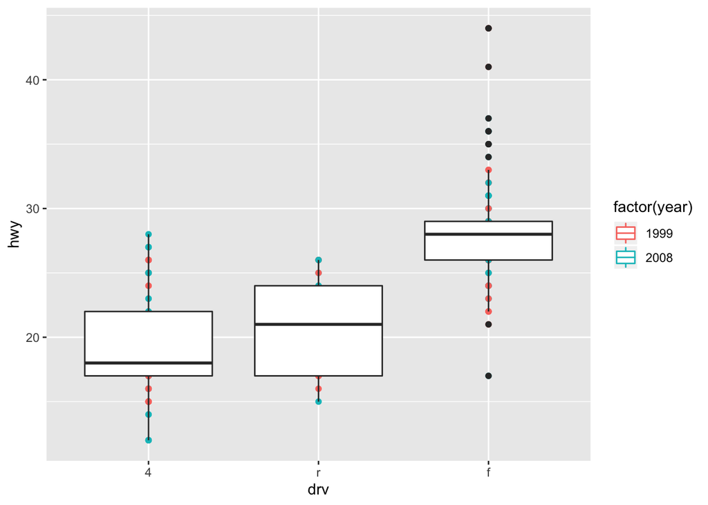

```r
## (a)
mpg %>% ggplot(aes(x = drv, y = hwy, color = factor(year))) + geom_point() +
  geom_boxplot(aes(group = drv))

## (b)
mpg %>% ggplot(aes(x = drv, y = hwy, color = factor(year))) +
  geom_point() + geom_boxplot()

## (c)
mpg %>% ggplot(aes(x = reorder(drv,hwy), y = hwy, color = factor(year))) +
  geom_point() + geom_boxplot()

## (d)
mpg %>% ggplot(aes(x = reorder(drv,hwy), y = hwy, color = factor(year))) +
  geom_point() + geom_boxplot(aes(group = drv))
```

Q2. Which code will reproduce the following figure ?

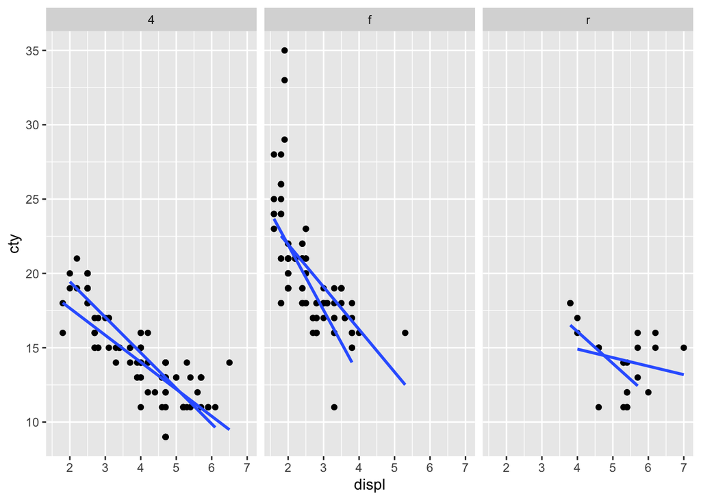

```r
## (a)
mpg %>% ggplot(aes(x = displ,  y = cty, color = year)) + geom_point() +
  stat_smooth(method = "lm", se = FALSE)

## (b)
mpg %>% ggplot(aes(x = displ,  y = cty, group = factor(year))) + geom_point() +
  stat_smooth(method = "lm", se = FALSE) + facet_wrap(~ drv)

## (c)
mpg %>% ggplot(aes(x = displ,  y = cty, color = year)) + geom_point() +
  stat_smooth() + facet_wrap(~ drv)

## (d)
mpg %>% ggplot(aes(x = displ,  y = cty, color = year)) + geom_point() +
  stat_smooth(aes(group = drv))
```